# Exercise Classifier

Matthew Thomas

2024-08-24

## Synopsis

Using devices such as Jawbone Up, Nike FuelBand, and Fitbit, it is now possible to collect a large amount of data about personal activity relatively inexpensively. This type of devices is part of the quantified self movement – a group of enthusiasts, who take measurements about themselves regularly to improve their health. One thing that people regularly do is quantify how much of a particular activity they do, but they rarely quantify how well they do it. In this project, our goal was to use data from accelerometers on the belt, forearm, arm, and dumbbell of six participants to assign a grade that rated how well they are exercising.

## Exploratory Analysis

```
## 'data.frame':    13737 obs. of  53 variables:
##  $ roll_belt           : num  -1 -1 -1 -1 -1 ...
##  $ pitch_belt          : num  0.344 0.344 0.344 0.344 0.345 ...
##  $ yaw_belt            : num  -0.874 -0.874 -0.874 -0.874 -0.874 ...
##  $ total_accel_belt    : num  -1.07 -1.07 -1.07 -1.07 -1.07 ...
##  $ gyros_belt_x        : num  0.0255 0.1225 0.0255 0.1225 0.1225 ...
##  $ gyros_belt_y        : num  -0.508 -0.508 -0.508 -0.508 -0.508 ...
##  $ gyros_belt_z        : num  0.459 0.459 0.459 0.417 0.459 ...
##  $ accel_belt_x        : num  -0.518 -0.552 -0.484 -0.552 -0.552 ...
##  $ accel_belt_y        : num  -0.915 -0.915 -0.88 -0.95 -0.95 ...
##  $ accel_belt_z        : num  0.943 0.943 0.952 0.933 0.933 ...
##  $ magnet_belt_x       : num  -0.912 -0.975 -0.897 -0.959 -0.928 ...
##  $ magnet_belt_y       : num  0.152 0.404 0.18 0.292 0.152 ...
##  $ magnet_belt_z       : num  0.505 0.536 0.628 0.551 0.536 ...
##  $ roll_arm            : num  -2.01 -2.01 -2.01 -2.01 -2.01 ...
```

[output cut: 39 more lines]

Overall, we have 13,737 observations in our training set with 52 features and the outcome `classe`, which is one of five grades: A, B, C, D, or E. We chose this combination of features because these are the features in the test set that aren’t missing values. We also chose to normalize the features because many multi-class classifiers require normalized data. For ease of analysis, we also converted the outcome to a factor variable.

Because we intended to use cross validation to determine the best classifier hyper-parameters and choose the best performing classifier, we divided the training data using a 70-30 split into training and validation data sets. So to evaluate the performance of the classifiers, we used the validation data, not the actual test data.

```
## [1] "Proportion of features over 80% correlated:"
```

```
## [1] 0.7169811
```

About 71.7% of features have correlation coefficients over 0.8. To account for this high amount of correlation, we pre-processed the data using Principal Component Analysis (PCA) to reduce the number of features.

## Classifier Models

Using accelerometer data on the belt, forearm, arm, and dumbell of the participants, the goal of the project is to predict how well they did their exercises. To determine how well they did the exercises, each exercise instance will be assigned one of five scores: A, B, C, D, or E.

While there are ways to do multi-class logistic regression, we chose not to try that approach because of the technique is overly complicated. Also, since there are a lot of correlations between our features, we didn’t attempt a Naive Bayes model because we can’t assume the features are independent.

Of the many types of multi-class classifiers left, they fall into one of three families: nearest neighbors, decision trees, and support vector machines. We chose to implement one classifier of each type and compare their performances.

To determine the best hyper-parameters for each classifier, we chose to use cross validation. As a nice compromise between accuracy and computational complexity, we used 10-fold cross validation repeated three times.

Because of the high number of highly correlated features, we used PCA to pre-process the data before training each classifier. We then made predictions about the validation data and compared the results. As a final stage of the analysis, we created two stacked models. For the first, we stacked the best performing pair of the classifiers. For the second one, we created a model consisting of all three of the classifiers, and compared the results of the stacked models to the single classifier models.

## Results:

### Baseline Classifiers:

```
## [1] "Proportions of each class in training data:"
```

```
##
##         A         B         C         D         E
## 0.2843416 0.1934920 0.1744195 0.1639368 0.1838101
```

#### Majority Class:

One common type of baseline classifier is the Majority-Class classifier. The Majority-Class classifier always assigns the most common label in the training data to any new data. In this case, the class `A` is the most frequent, and assuming the new data has the same distribution of labels as the training data, we’d be correct about 28.4% of the time.

#### Random Rate (Weighted Guessing):

Another common type of baseline classifier is the Random-Rate classifier. In the case of the Random-Rate classifier, we assign class labels based on the class distribution in the training data. In this case, we would randomly assign class A to 28.4% of the new observations, class B to 19.4% of the time, class C 17.4%, etc. The theoretical baseline accuracy using this strategy would be:

```
## [1] "combined_accuracy = (proportion A)^2 + (proportion B)^2 + ..."
```

```
##         A
## 0.2093729
```

So we would expect to be correct about 20.9% of the time.

### k-Nearest Neighbor:

*k-Nearest Neighbor classifier with PCA Pre-processing:*

```
##   k  Accuracy
## 1 5 0.9522931
## 2 7 0.9382193
## 3 9 0.9249711
```

Overall, the most accurate k-Nearest Neighbor classifier used 5 nearest neighbors, and had an accuracy of 95.2% on the training data.

*Results of prediction with this classifier:*

```
##       Accuracy  AccuracyLower  AccuracyUpper AccuracyPValue
##      0.9612574      0.9560080      0.9660430      0.0000000
```

Using the classifier to make predictions on the validation data, our accuracy estimate is 96.1%, and we’re 95% sure that the real value is between 95.6% and 96.6%.

### Support Vector Machine(SVM):

Because we assume that there are non-linear associations between the features, we chose to use the Radial Basis Function (RBF) kernel method for the SVM classifier, because it performs well with this type of data.

*SVM classifier with PCA Pre-processing:*

```
##        sigma    C  Accuracy
## 1 0.02597365 0.25 0.8382246
## 2 0.02597365 0.50 0.8715411
## 3 0.02597365 1.00 0.9043000
```

During cross validation, the best sigma value was estimated to be about 0.026, and holding this value constant, the best performing SVM classifier had a C value of 1.0. On the training data, its accuracy was 90.4%.

*Results of prediction with this classifier:*

```
##       Accuracy  AccuracyLower  AccuracyUpper AccuracyPValue
##      0.9051827      0.8974106      0.9125503      0.0000000
```

Using these hyper-parameters, the SVM was about 90.5% accurate on the validation data. We’re 95% sure that the actual accuracy is between 89.7% and 91.3%.

### Decision Trees:

As the best performing type of Decision Tree, we chose to use the Random Forest classifier.

*Random Forest classifier with PCA Pre-processing:*

```
##   mtry  Accuracy
## 1    2 0.9723136
## 2   27 0.9606416
## 3   52 0.9602532
```

During cross validation, we determined the best `mtry` value, the number of features randomly sampled as candidates at each split, was 2. With this `mtry` the Random Forest classifier was 97.2% accurate on the training data.

*Results of prediction with this classifier:*

```
##       Accuracy  AccuracyLower  AccuracyUpper AccuracyPValue
##      0.9695837      0.9648718      0.9738221      0.0000000
```

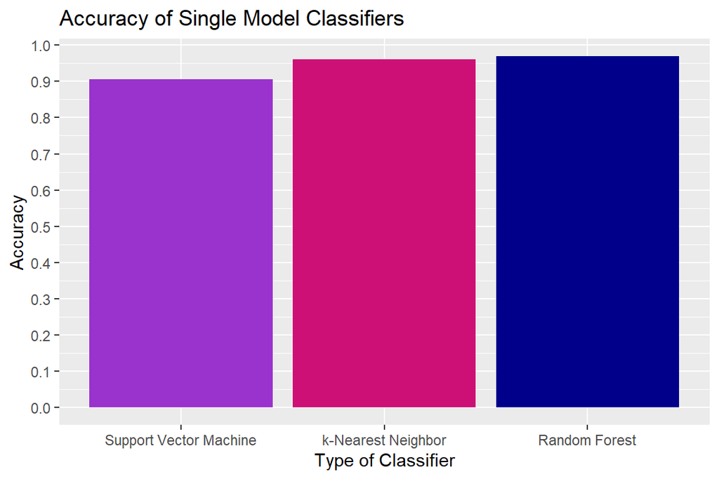

Comparing the single model classifiers, the k-Nearest Neighbor and the Random Forest classifiers were the best performing classifiers.

### Stacked Models:

In addition to these single model classifiers, we created two stacked model classifiers. For the first, we combined our two best performing classifiers, the k-Nearest Neighbor and the Random Forest, and for the second we combined all three classifiers. By combining the models, we hoped to improve overall performance.

Since the k-Nearest Neighbor and SVM classifiers require the data to be normalized, and the data in stacked model are the assigned labels from the other classifiers, we chose to use the Random Forest classifier for the stacked model. It was also our best performing classifier.

*Stacked k-Nearest Neighbor and Random Forest classifier:*

```
##   mtry  Accuracy
## 1    2 0.9713954
## 2    5 0.9723018
## 3    8 0.9722447
```

For the stacked model that combines our k-Nearest Neighbor and Random Forest classifiers, the accuracy was 97.2% with an `mtry` of 5.

*Results of prediction with this classifier:*

```
##       Accuracy  AccuracyLower  AccuracyUpper AccuracyPValue
##      0.9731521      0.9686955      0.9771309      0.0000000
```

*Stacked k-Nearest Neighbor, Random Forest and SVM classifier:*

```
##   mtry  Accuracy
## 1    2 0.9733785
## 2    7 0.9723031
## 3   12 0.9720199
```

The accuracy on the training data for our stacked model combining all three classifiers was 97.3% with an `mtry` of 2.

*Results of prediction with this classifier:*

```
##       Accuracy  AccuracyLower  AccuracyUpper AccuracyPValue
##      0.9743415      0.9699741      0.9782297      0.0000000
```

By combining all three classifiers, our accuracy estimate was 97.4%, and we’re 95% sure that the true accuracy is between 97.0% and 97.8%.

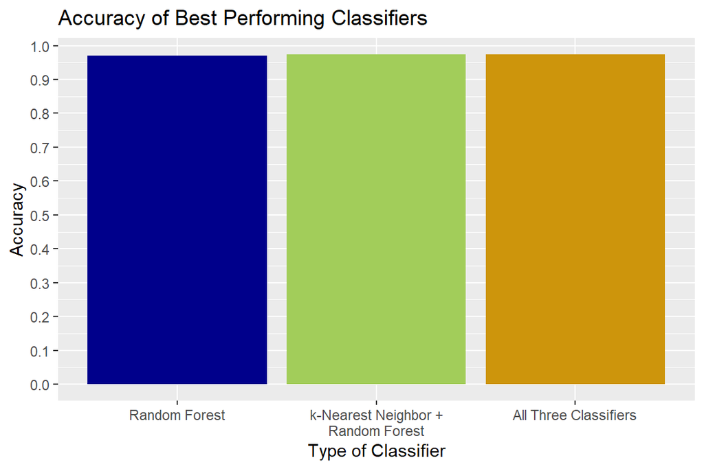

## Conclusions

Overall, our best performing classifiers achieved accuracy rates above 97%. Compared to a Random Rate baseline classifier, our classifiers added over 75% of value, and compared to a Majority Vote baseline classifier, we added almost 70% of value.